# Project 3 (Red Wine Quality Analysis) by Mihir Majmundar

# Final Plots and Summary

### Plot One

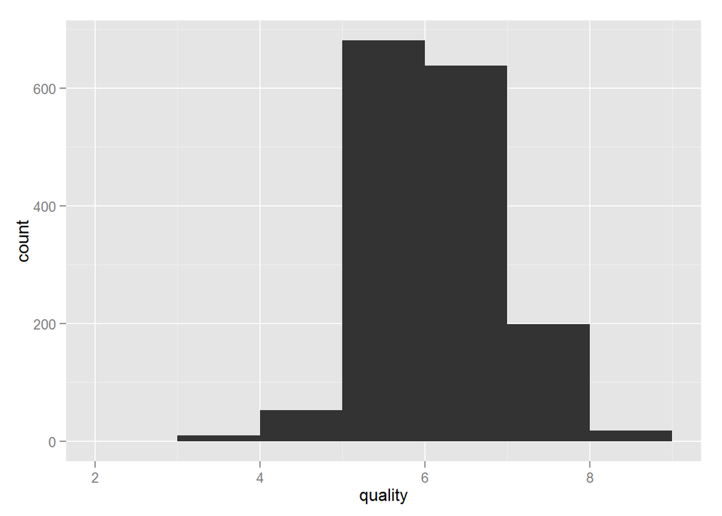

### Description One

Histogram of Quality which is the output feature of the wine data. The data is collected on different features including quality of the wine. Histogram shows almost perfect bell curve. Median of the quality data is 6. Mean value is 5.636.

### Plot Two

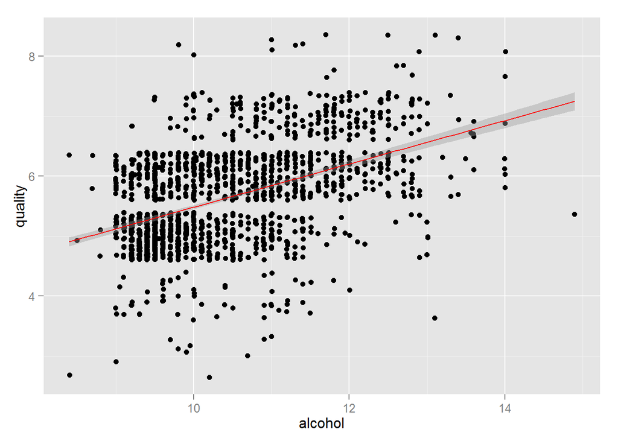

### Description Two

From the data summary, I found that alcohol has strongest linear relationship with quality among all features. R value is 0.475. Scatter plot shows some linear relationship. I have added smooth line to show the trend.

### Plot Three

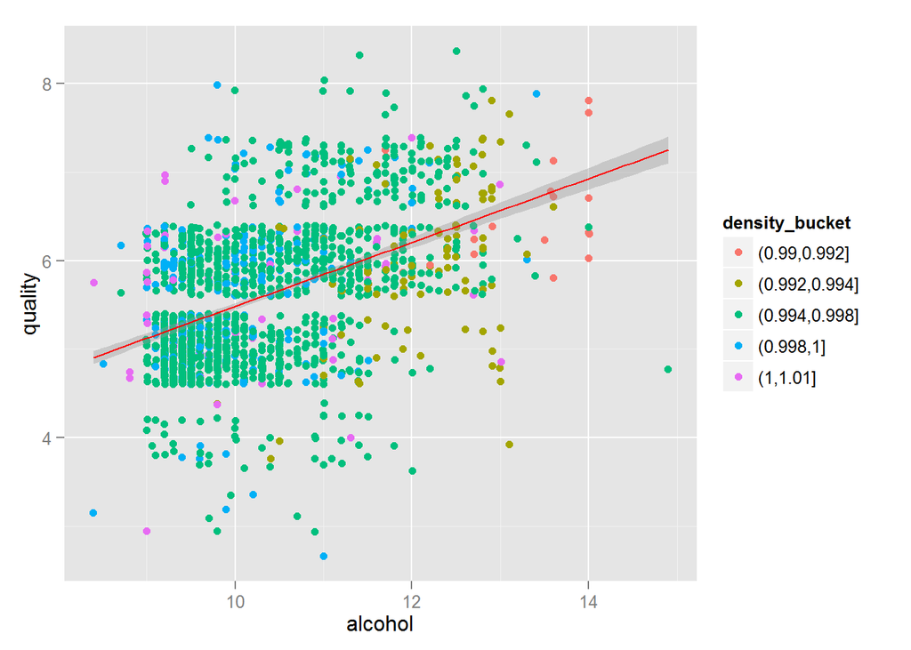

### Description Three

After finding alcohol and quality near to strong relationship, density was interesting features. There are many weak and strong relationship of other features on density. Alcohol was one the strong features and it was with negative relationship.

The chart shows that as value of alcohol increases, it reduce the density and lower value of alcohol increases the density. so lower the density value improve the quality of the wine. relationship between density and quality is also negative. So these two features alcohol and density make more sense to keep it together.

# Reflection

Red Wine data has 1599 observations. There are 11 input features and one output features. Here we are trying to find which feature is impacting the quality of the wine. How strongly they are related to the quality.

Among all input features, alcohol has moderate relationship with quality. I found some other interesting fact that, total sulfur dioxide and free sulfur dioxide are strongly related but total sulfur dioxide has more impact on quality than free sulfur dioxide. There were few acidic features has strong and moderate relationship with pH but pH has very weak relationship with Quality. There acidic features have some weak relationship with quality. I was surprise seeing the result that pH level has almost no impact on quality of the wine.

In summary, Test results(input features) for wine and quality of the wine are not related strongly. After creating the model it comes to very R value which suggest that they have weak linear relationship. For higher level of confidence and linearly we need to get some more data point and impacting features. Given features are not enough to predict the quality of the wine.